# Part II - (FordGoBike Data Analysis)

## by (Okeri Mwikali Josephine)

# Features Determining Bike Ride Durations

## Investigation Overview

In this investigation, I wanted to look at the features that could be used to predict bike ride durations. The main focus was on the Birth year of the rider,User type, Gender,hours and days of the week,Bike share.

## Dataset Overview

- This data set consist of 183 000 rides made in a bike-sharing system covering the greater San Francisco Bay area. The dataset include the following features rider duration, Stations, time, gender of the rider and also user type.
- The dataset had some missing values in some row were removed.
- The start time and end time column had some data that were extracted lead to addition of number of columns

### Data Cleaning

### Issue

- Missing Values on start_station_id ,start_station_name,end_station_id,end_station_name,member_birth_year and member_gender
- Start_time and End_time have wrong data types as object
- Bike_id wrong data type
- Extract Hour, day and month from the start_time and end_time

## Distribution of Duration

The distribution of duration take unimodal shape,Average durations were at 500 seconds

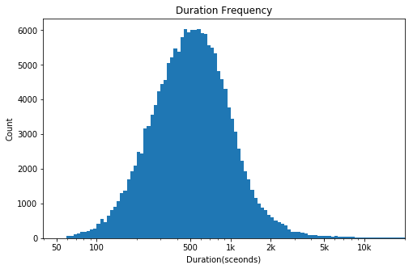

## Frequencies for Bike share,Gender and User Type

- Most riders do not share bike
- Most riders were male
- Most of the rider are the subscriber

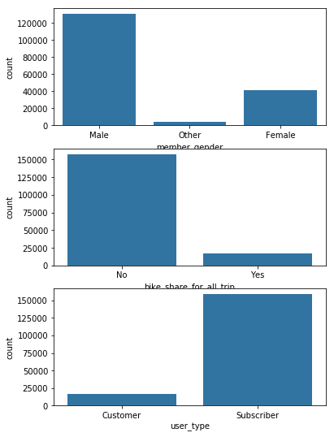

## Distribution of Member Birth

Most bike rider Members were born in 1985 to 1995

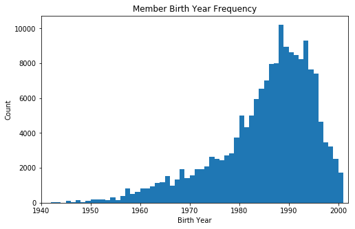

## Duration Vs Member Birth Year

Most frequent bike riders were born in 1980s to 1995 showing that most young people tend to ride bike for long distance compared to old people who we born earlier.

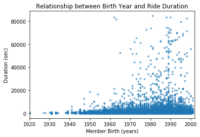

## Bike share, User type and Gender

Customers didn't share bike compared to subscriber share their bike,also most subscriber did not share the bike. Most male did not share their bike recorded high count but comparing with the other gender it show most male share their bike while the other group of gender come last. Most male who ride the bike were subscribers.

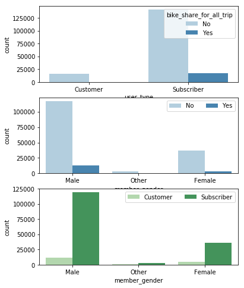

## Duration And Member Birth Year by User Type

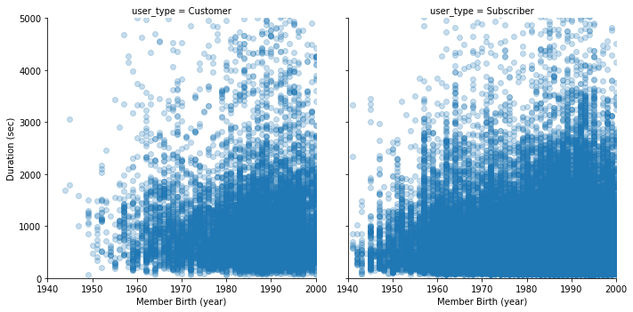

## Duration by start day and Bike share

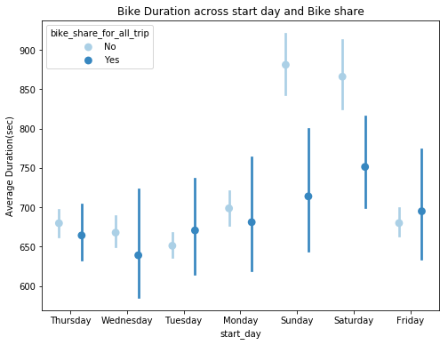

## Gender, Bike share on Birth Year

The other gender that share bike most were born between 1982 and 1984.

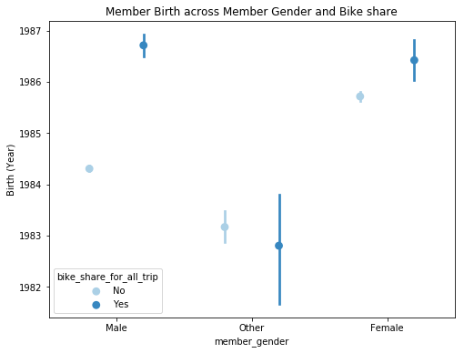